# Geospatial Analysis of a Changing Road Network, 11-17-2025

Author

Will Jones

# Methods

### Data Acquisition and Preprocessing

US Census Bureau’s TIGER/Line vector files were used as the road networks in this project. The most recently available 2024 road network data for the conterminous United States was downloaded in bulk using the `roads()` function from the Python package `pygris` (“Pygris,” n.d.).

Comparable data for the year 2000 was downloaded from the archived Census FTP site `(https://www2.census.gov/geo/tiger/tiger2k/)`, and a multi-step data preprocessing workflow was performed before the data was implemented in the analysis workflow. First, `beautifulsoup4` was used to download vector dataset in `RT1` format, the historical file format for census geographic data (Richardson 2007). Using GDAL command-line utilities, files were converted to modern shapefile format, then merged into a single dataset using `geopandas` in Python (Jordahl et al. 2020). Finally, feature correction was performed using geometry-snapping and densification processing using QGIS 3.36 “Maidenhead.” To rectify data quality issues, namely feature accuracy and spatial mismatch between existing roads in the 2000 and 2024 datasets, the historical vector dataset was densified at regular 25m intervals, then snapped to the nearest matching feature in the current roads dataset. This was done to avoid erroneous measurement differences in distance to the nearest road for each year that may be incorrectly attributed to removal or addition of a new road feature.

`EPSG:5070, NAD 83 CONUS Albers | Unit: m`

Summary Statistics

| Year | Mean | SD | Min | 1st quartile | Median | 3rd Quartile | Max |
| --- | --- | --- | --- | --- | --- | --- | --- |
| 2000 | 289.29 | 425.65 | 0.00004 | 74.80 | 188.47 | 376.25 | 12963.61 |
| 2024 | 214.83 | 342.06 | 0.00031 | 52.93 | 132.74 | 270.36 | 12892.76 |

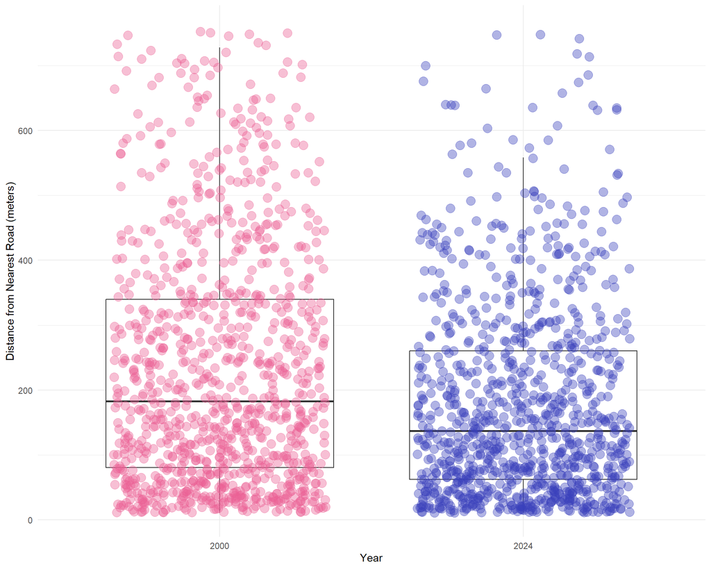

Distribution of Paired Sample Points

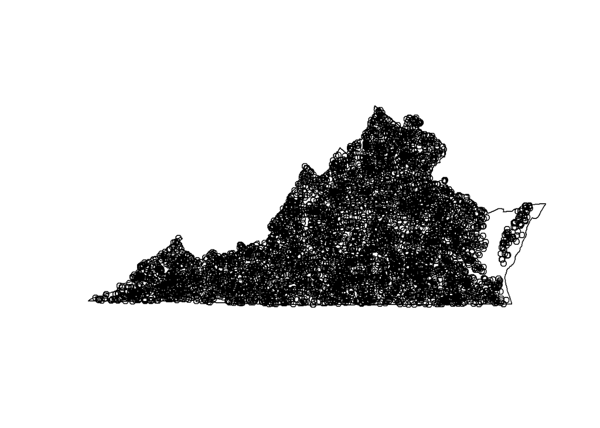

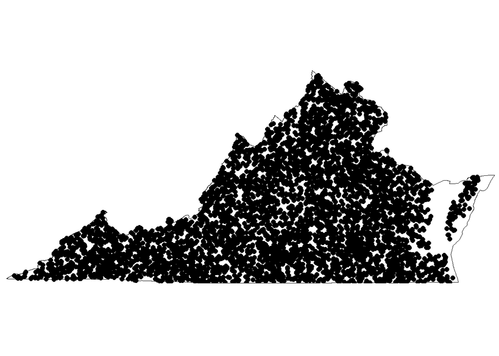

[figure not shown]

## Abbreviations

- **3DHP** 3D Hydrography Program
- **EPA** Environmental Protection Agency
- **GDAL** Geospatial Data Abstraction Library
- **HUC** Hydrologic Unit Code
- **NLCD** National Land Cover Database
- **TIGER** Topologically Integrated Geographic Encoding and Referencing
- **USGS** United States Geoglogical Survey

## References

“Annual NLCD Collection 1 Science Products.” 2024. US Geological Survey (USGS).

Jordahl, Kelsey, Joris Van den Bossche, Martin Fleischmann, Jacob Wasserman, James McBride, Jeffrey Gerard, Jeff Tratner, et al. 2020. “Geopandas/Geopandas: V0.8.1.” Zenodo. https://doi.org/10.5281/zenodo.3946761.

“Pygris.” n.d. https://walker-data.com/pygris/.

Richardson, Leonard. 2007. “Beautiful Soup Documentation.” *April*.